# CP06_2

Jose López Galdón

2020-12-10

Comenzaremos visualizando los datos que tenemos:

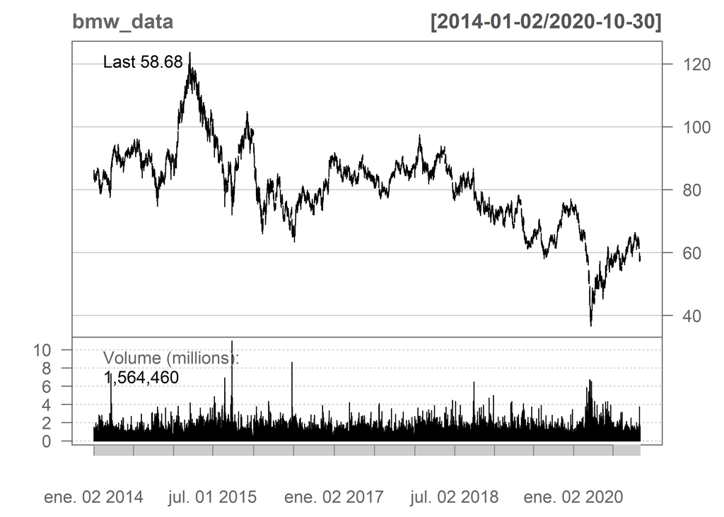

```r
  # Para visualizar la cotización de los activos utilizaremos la función barChart()

  # BMW:
barChart(bmw_data, theme = "white.mono")
```

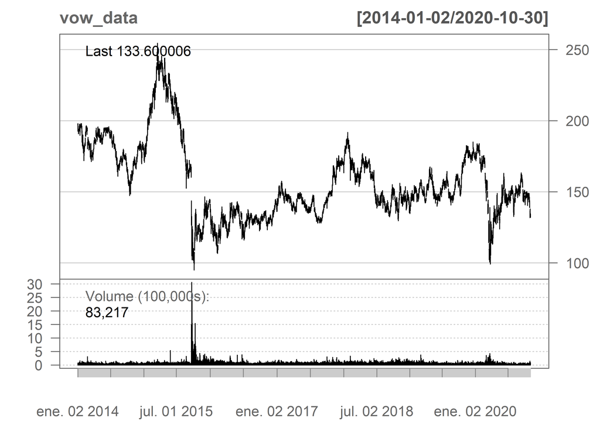

```r
  # Volkswagen:
barChart(vow_data, theme = "white.mono")
```

En el gráfico de Volkswagen, podemos ver claramente el efecto del **diseslgate**: *En septiembre de 2015 salió a la luz que Volkswagen había instalado ilegalmente un software para alterar los resultados de los controles técnicos de emisiones contaminantes en 11 millones de automóviles con motor diésel, vendidos entre 2009 y 2015. Como resultado de este fraude, sus motores habían superado con creces los estándares de la Agencia de Protección Ambiental de Estados Unidos (EPA). Los vehículos implicados emiten en condiciones reales hasta 40 veces el límite legal de óxidos de nitrógeno.*

## COINTEGRACIÓN

El análisis de series temporales se encuentra con un problema al medir las relaciones entre aquellas variables que tienen una tendencia temporal.

Este problema puede llegar a que se consideren significativas relaciones completamente espurias.

Las variables que tienen una tendencia temporal definida se denominan “no estacionarias”.

Las estimaciones de regresiones con variables no estacionarias son espurias salvo que estas estén cointegradas.

Dos variables no estacionarias cointegradas son aquellas cuyos residuos son estacionarios.

Si los residuos son estacionarios las estimaciones de variables no estacionarias son superconsistentes.

```r
  # Unimos los dos dtasets con los precios ajustados
pair_trade <- cbind(bmw_data$BMW.DE.Adjusted, vow_data$VOW.DE.Adjusted)

  # Eliminamos los na en ambas series
pair_trade <- na.exclude(pair_trade)

  # Comprobamos el resultado
head(pair_trade)
```

```
##            BMW.DE.Adjusted VOW.DE.Adjusted
## 2014-01-02        62.47273        167.4914
## 2014-01-03        62.80178        166.6702
## 2014-01-06        62.06143        166.1515
## 2014-01-07        62.48022        167.3185
## 2014-01-08        63.15325        167.0160
## 2014-01-09        62.71204        166.8431
```

### ¿Son estacionarias?

```r
  # Para BMW
adf.test(pair_trade[, 1],k = 0)
```

```
##
##  Augmented Dickey-Fuller Test
##
## data:  pair_trade[, 1]
## Dickey-Fuller = -3.1533, Lag order = 0, p-value = 0.09597
## alternative hypothesis: stationary
```

```r
  # Para volkswagen
adf.test(pair_trade[, 2],k = 0)
```

```
##
##  Augmented Dickey-Fuller Test
##
## data:  pair_trade[, 2]
## Dickey-Fuller = -2.6022, Lag order = 0, p-value = 0.3234
## alternative hypothesis: stationary
```

```r
  # Calculamos el test para bmw sin tendencia por AIC y con 10 lags
test_notrend <- ur.df(pair_trade[, 1], type = "none", selectlags = "AIC", lags = 10)
summary(test_notrend)
```

```
##
## ###############################################
## # Augmented Dickey-Fuller Test Unit Root Test #
## ###############################################
##
## Test regression none
##
##
## Call:
## lm(formula = z.diff ~ z.lag.1 - 1 + z.diff.lag)
##
## Residuals:
##     Min      1Q  Median      3Q     Max
## -5.9752 -0.5738  0.0006  0.5802  5.5018
##
## Coefficients:
##               Estimate Std. Error t value Pr(>|t|)
## z.lag.1     -0.0001740  0.0003875  -0.449   0.6535
## z.diff.lag1  0.0523740  0.0241226   2.171   0.0301 *
## z.diff.lag2  0.0131118  0.0241259   0.543   0.5869
## z.diff.lag3  0.0486836  0.0241910   2.012   0.0443 *
## z.diff.lag4 -0.0508074  0.0242012  -2.099   0.0359 *
## ---
## Signif. codes:  0 '***' 0.001 '**' 0.01 '*' 0.05 '.' 0.1 ' ' 1
##
## Residual standard error: 1.099 on 1714 degrees of freedom
## Multiple R-squared:  0.007654,   Adjusted R-squared:  0.004759
## F-statistic: 2.644 on 5 and 1714 DF,  p-value: 0.02174
##
##
## Value of test-statistic is: -0.449
##
## Critical values for test statistics:
##       1pct  5pct 10pct
## tau1 -2.58 -1.95 -1.62
```

Vemos como necesita una diferencia. Ahora probaremos con tendencia:

```r
  # Calculamos el test para bmw sin tendencia por AIC y con 10 lags
test_trend <- ur.df(pair_trade[, 1], type = "trend", selectlags = "AIC", lags = 10)
summary(test_trend)
```

```
##
## ###############################################
## # Augmented Dickey-Fuller Test Unit Root Test #
## ###############################################
##
## Test regression trend
##
##
## Call:
## lm(formula = z.diff ~ z.lag.1 + 1 + tt + z.diff.lag)
##
## Residuals:
##     Min      1Q  Median      3Q     Max
## -6.1095 -0.5815 -0.0066  0.5677  5.2121
##
## Coefficients:
##               Estimate Std. Error t value Pr(>|t|)
## (Intercept)  8.829e-01  2.639e-01   3.346 0.000838 ***
## z.lag.1     -1.181e-02  3.533e-03  -3.343 0.000846 ***
## tt          -9.614e-05  5.738e-05  -1.676 0.093999 .
## z.diff.lag1  5.719e-02  2.411e-02   2.373 0.017773 *
## z.diff.lag2  1.851e-02  2.412e-02   0.768 0.442888
## z.diff.lag3  5.425e-02  2.419e-02   2.243 0.025043 *
## z.diff.lag4 -4.470e-02  2.421e-02  -1.846 0.065035 .
## ---
## Signif. codes:  0 '***' 0.001 '**' 0.01 '*' 0.05 '.' 0.1 ' ' 1
##
## Residual standard error: 1.096 on 1712 degrees of freedom
## Multiple R-squared:  0.0141, Adjusted R-squared:  0.01064
## F-statistic:  4.08 on 6 and 1712 DF,  p-value: 0.0004527
##
##
## Value of test-statistic is: -3.3434 3.8025 5.6981
##
## Critical values for test statistics:
##       1pct  5pct 10pct
## tau3 -3.96 -3.41 -3.12
## phi2  6.09  4.68  4.03
## phi3  8.27  6.25  5.34
```

Los valores de los estadísticos son -3.3434, 3.8025 y 5.6981, por lo que estamos en H0.